# PRICE FORECASTING USING ARIMA AND REGRESSION MODELS

**Dataset:** Tesla Stock Data (Daily)

**Author**:Brian Wasike

## 1. Project Objectives

The second objective is to evaluate and compare the predictive accuracy of the two models using a held-out test dataset.

### **c. Identify the Superior Forecasting Model**

The final objective is to determine which model performs better overall for the forecasting task.

## 2.project Summary

This project aimed to forecast Tesla stock prices using ARIMA and a Regression model. The two models were trained on historical closing prices and evaluated on a 60-day test set. Performance was compared using RMSE, and MAPE. Results show that ARIMA outperformed Regression, indicating that time-series specific models provide more accurate short-term forecasts for stock data.

## 3. Inroduction

Stock price forecasting helps investors and analysts predict future market movements. ARIMA is a classical time-series model, while Regression uses explanatory variables and historical lags. This study compares the two approaches to determine which performs better on Tesla stock data.

## Dataset Description: Tesla Stock Data

[output not shown]

### Data Cleaning Steps

The initial data cleaning focuses on preparing the time series for modeling by ensuring correct data types and handling missing values.

1. **Date Conversion and Indexing:**
   - The `Date` column is converted from a string object to a proper **datetime** object.
   - The `Date` column is then set as the **index** of the DataFrame, which is essential for time series analysis.
2. **Target Selection and Null Handling:**
   - The **'Close'** price column is specifically selected as the target variable.
   - Any rows with missing values (**NaN**) in the 'Close' price are **dropped** (`.dropna()`) to ensure a continuous and clean time series for modeling.
3. **Regression Feature Preparation:**
   - For the Regression model, an implicit cleaning step involves creating **lagged features** (e.g., $\text{Close}_{t-1}, \text{Close}_{t-2}$), which requires dropping the first few rows of the data where the lagged values are naturally missing ($\text{NaN}$).

```python
import pandas as pd
import numpy as np
import matplotlib.pyplot as plt
import seaborn as sns
from math import sqrt
from sklearn.linear_model import LinearRegression
from sklearn.metrics import mean_squared_error, mean_absolute_error
import warnings
warnings.filterwarnings("ignore")
```

```python
np.random.seed(42)
plt.style.use('ggplot')
```

```python
import zipfile
import os

zip_path = r"C:\Users\hp\Downloads\archive (7) (1).zip"

extract_dir = r"C:\Users\hp\Downloads\Tesla_stock_data"
os.makedirs(extract_dir, exist_ok=True)

with zipfile.ZipFile(zip_path, 'r') as zip_ref:
    zip_ref.extractall(extract_dir)

print(" Extracted files to:", extract_dir)
print("Files inside:")
print(os.listdir(extract_dir))
```

```
 Extracted files to: C:\Users\hp\Downloads\Tesla_stock_data
Files inside:
['Tesla_stock_data.csv']
```

```python
import pandas as pd

path = r"C:\Users\hp\Downloads\Tesla_stock_data\Tesla_stock_data.csv"

stock_df = pd.read_csv(path)

print(" Dataset loaded successfully!")
print("Shape:", stock_df.shape)
print("Columns:", list(stock_df.columns))
stock_df.head()
```

```
 Dataset loaded successfully!
Shape: (3861, 6)
Columns: ['Date', 'Close', 'High', 'Low', 'Open', 'Volume']
```

|  | Date | Close | High | Low | Open | Volume |
| --- | --- | --- | --- | --- | --- | --- |
| 0 | 2010-06-29 | 1.592667 | 1.666667 | 1.169333 | 1.266667 | 281494500 |
| 1 | 2010-06-30 | 1.588667 | 2.028000 | 1.553333 | 1.719333 | 257806500 |
| 2 | 2010-07-01 | 1.464000 | 1.728000 | 1.351333 | 1.666667 | 123282000 |
| 3 | 2010-07-02 | 1.280000 | 1.540000 | 1.247333 | 1.533333 | 77097000 |
| 4 | 2010-07-06 | 1.074000 | 1.333333 | 1.055333 | 1.333333 | 103003500 |

**Exploritory Data Analysis**

## statistical summary

```python
import pandas as pd

# Load the dataset
file_name = "Tesla_stock_data[1].csv"
df = pd.read_csv(file_name)

# Convert 'Date' to datetime and set as index
df['Date'] = pd.to_datetime(df['Date'])
df.set_index('Date', inplace=True)

# Select only the numerical columns for the summary
numerical_df = df[['Close', 'High', 'Low', 'Open', 'Volume']]
summary_df = numerical_df.describe().T
summary_df['count'] = summary_df['count'].astype(int)

cols_to_format = ['mean', 'std', 'min', '25%', '50%', '75%', 'max']

summary_df.loc[['Close', 'High', 'Low', 'Open'], cols_to_format] = \
    summary_df.loc[['Close', 'High', 'Low', 'Open'], cols_to_format].round(2)
summary_df.loc['Volume', cols_to_format] = \
    summary_df.loc['Volume', cols_to_format].fillna(0).astype(int)

print("--- Statistical Summary of Tesla Stock Data ---")
print(summary_df.to_markdown())
summary_df.to_csv('statistical_summary.csv', index=True)
```

```
--- Statistical Summary of Tesla Stock Data ---
|        |   count |         mean |           std |        min |          25% |          50% |           75% |           max |
|:-------|--------:|-------------:|--------------:|-----------:|-------------:|-------------:|--------------:|--------------:|
| Close  |    3861 | 95.51        | 120.76        | 1.05       | 12.71        | 19.65        | 202.04        | 479.86        |
| High   |    3861 | 97.63        | 123.5         | 1.11       | 12.92        | 20           | 207.16        | 488.54        |
| Low    |    3861 | 93.27        | 117.9         | 1          | 12.47        | 19.24        | 197.85        | 457.51        |
| Open   |    3861 | 95.52        | 120.82        | 1.08       | 12.67        | 19.63        | 202.03        | 475.9         |
| Volume |    3861 |  9.69247e+07 |   7.60524e+07 | 1.7775e+06 |  5.10942e+07 |  8.33445e+07 |   1.21988e+08 |   9.14082e+08 |
```

```python
import pandas as pd

df = pd.read_csv(r"C:\Users\hp\Downloads\Tesla_stock_data\Tesla_stock_data.csv")
df.head()
df['Date'] = pd.to_datetime(df['Date'])
```

```python
df.info()
df.describe()
df.isnull().sum()
```

```
<class 'pandas.core.frame.DataFrame'>
RangeIndex: 3861 entries, 0 to 3860
Data columns (total 6 columns):
 #   Column  Non-Null Count  Dtype
---  ------  --------------  -----
 0   Date    3861 non-null   datetime64[ns]
 1   Close   3861 non-null   float64
 2   High    3861 non-null   float64
 3   Low     3861 non-null   float64
 4   Open    3861 non-null   float64
 5   Volume  3861 non-null   int64
dtypes: datetime64[ns](1), float64(4), int64(1)
memory usage: 181.1 KB
```

```
Date      0
Close     0
High      0
Low       0
Open      0
Volume    0
dtype: int64
```

**closing Over Time**

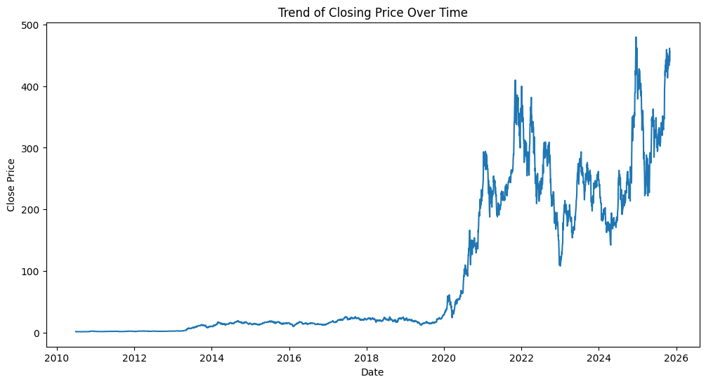

```python
import matplotlib.pyplot as plt
plt.figure(figsize=(12,6))
plt.plot(df['Date'], df['Close'])
plt.title("Trend of Closing Price Over Time")
plt.xlabel("Date")
plt.ylabel("Close Price")
plt.show()
```

**Volume Over Time**

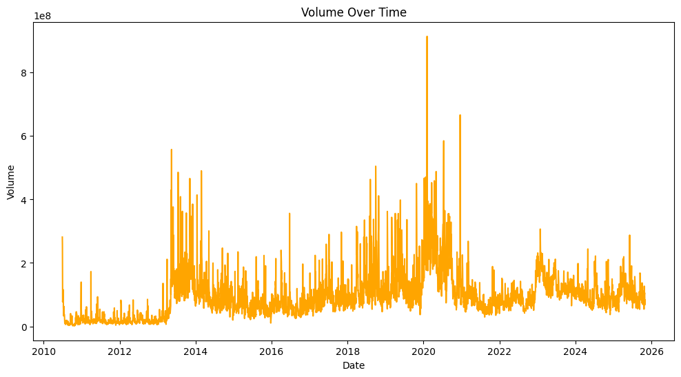

```python
plt.figure(figsize=(12,6))
plt.plot(df['Date'], df['Volume'], color='orange')
plt.title("Volume Over Time")
plt.xlabel("Date")
plt.ylabel("Volume")
plt.show()
```

**Boxplots (Check for Outliers)**

|  | Date | Close | High | Low | Open | Volume |
| --- | --- | --- | --- | --- | --- | --- |
| 0 | 2010-06-29 | 1.592667 | 1.666667 | 1.169333 | 1.266667 | 281494500 |
| 1 | 2010-06-30 | 1.588667 | 2.028000 | 1.553333 | 1.719333 | 257806500 |
| 2 | 2010-07-01 | 1.464000 | 1.728000 | 1.351333 | 1.666667 | 123282000 |
| 3 | 2010-07-02 | 1.280000 | 1.540000 | 1.247333 | 1.533333 | 77097000 |
| 4 | 2010-07-06 | 1.074000 | 1.333333 | 1.055333 | 1.333333 | 103003500 |

```
Outlier counts per column:
```

```
Close_outlier       0
High_outlier        0
Low_outlier         0
Open_outlier        0
Volume_outlier    215
dtype: int64
```

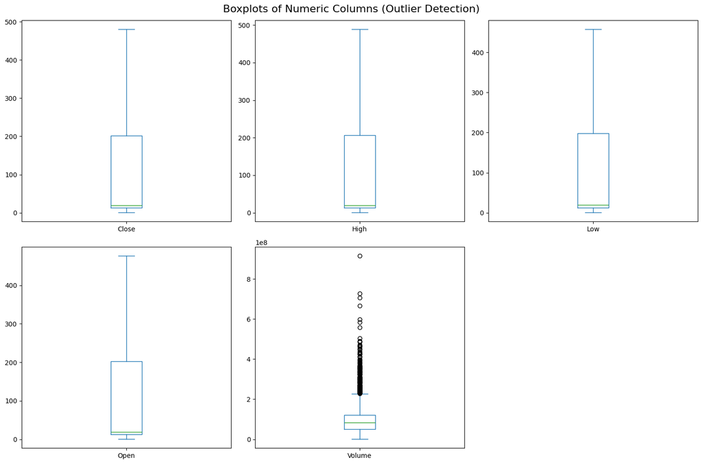

```python
df['Date'] = pd.to_datetime(df['Date'])

display(df.head())
numeric_cols = df.select_dtypes(include='number').columns

outlier_df = df.copy()

for col in numeric_cols:
    Q1 = df[col].quantile(0.25)
    Q3 = df[col].quantile(0.75)
    IQR = Q3 - Q1

    lower_bound = Q1 - 1.5 * IQR
    upper_bound = Q3 + 1.5 * IQR

    outlier_df[col + '_outlier'] = np.where(
        (df[col] < lower_bound) | (df[col] > upper_bound),
        True,
        False
    )
print("Outlier counts per column:")
display(outlier_df.filter(like='_outlier').sum())
plt.figure(figsize=(14, 8))
df[numeric_cols].plot(kind='box', subplots=True, layout=(2, 3), figsize=(15, 10))
plt.suptitle("Boxplots of Numeric Columns (Outlier Detection)", fontsize=16)
plt.tight_layout()
plt.show()
```

```python
# Convert index to datetime
df.index = pd.to_datetime(df.index)

# Define time series
ts_series = df['Close'].asfreq('B').ffill()

ts_series.head()
```

```
Date
2010-06-29    1.592667
2010-06-30    1.588667
2010-07-01    1.464000
2010-07-02    1.280000
2010-07-05    1.280000
Freq: B, Name: Close, dtype: float64
```

**FORECASTING**

```python
first_col = df.columns[0]
if first_col.lower().startswith("unnamed") or df[first_col].dtype == object and df[first_col].str.contains(r'1970-01-01').any():
    print(f"Dropping first column '{first_col}' (likely exported index).")
    df = df.drop(columns=[first_col])
```

```python
date_candidates = [c for c in df.columns if c.lower() in ['date','datetime','timestamp','day']]
if len(date_candidates) == 0:
    for c in df.columns:
        try:
            pd.to_datetime(df[c].iloc[:5])
            date_candidates = [c]
            break
        except Exception:
            continue

if len(date_candidates)==0:
    raise ValueError("No date-like column found. Please ensure the CSV has a Date column.")
date_col = date_candidates[0]
print("Using date column:", date_col)
```

```
Using date column: Date
```

```python
df[date_col] = pd.to_datetime(df[date_col])
df = df.sort_values(date_col).reset_index(drop=True)
df = df.set_index(date_col)
```

```python
close_candidates = [c for c in df.columns if c.lower() in ['close','adj close','adj_close','close_price','closeprice']]
if len(close_candidates)==0:
    numeric_cols = df.select_dtypes(include='number').columns.tolist()
    if not numeric_cols:
        raise ValueError("No numeric columns found to act as 'Close' price.")
    close_col = numeric_cols[-1]
else:
    close_col = close_candidates[0]

print("Using close column:", close_col)
df[close_col] = pd.to_numeric(df[close_col], errors='coerce')
```

```
Using close column: Close
```

```python
df = df.ffill().bfill()
print("\nCleaned head:")
display(df.head())
print("\nData info:")
display(df.info())
```

```
Cleaned head:
```

| Date | Close | High | Low | Open | Volume |
| --- | --- | --- | --- | --- | --- |
| 2010-06-29 | 1.592667 | 1.666667 | 1.169333 | 1.266667 | 281494500 |
| 2010-06-30 | 1.588667 | 2.028000 | 1.553333 | 1.719333 | 257806500 |
| 2010-07-01 | 1.464000 | 1.728000 | 1.351333 | 1.666667 | 123282000 |
| 2010-07-02 | 1.280000 | 1.540000 | 1.247333 | 1.533333 | 77097000 |
| 2010-07-06 | 1.074000 | 1.333333 | 1.055333 | 1.333333 | 103003500 |

```
Data info:
<class 'pandas.core.frame.DataFrame'>
DatetimeIndex: 3861 entries, 2010-06-29 to 2025-10-31
Data columns (total 5 columns):
 #   Column  Non-Null Count  Dtype
---  ------  --------------  -----
 0   Close   3861 non-null   float64
 1   High    3861 non-null   float64
 2   Low     3861 non-null   float64
 3   Open    3861 non-null   float64
 4   Volume  3861 non-null   int64
dtypes: float64(4), int64(1)
memory usage: 181.0 KB
```

```
None
```

```python
ts_index = pd.date_range(start=df.index.min(), end=df.index.max(), freq='B')
df_ts = df.reindex(ts_index)
```

```python
for col in df_ts.select_dtypes(include='number').columns:
    df_ts[col] = df_ts[col].ffill().bfill()

ts_series = df_ts[close_col].astype(float)
print("\nTime series length:", len(ts_series))

if len(ts_series) < 30:
    raise ValueError("Not enough data for forecasting. Need at least ~30 observations. Found: {}".format(len(ts_series)))
```

```
Time series length: 4004
```

## Train/test split

```python
h = min(60, max(10, int(len(ts_series) * 0.1)))
if len(ts_series) - h < 20:
    h = max(10, len(ts_series) - 20)
print("Forecast horizon h =", h)

train = ts_series.iloc[:-h]
test = ts_series.iloc[-h:]
print("Train size:", len(train), "Test size:", len(test))
```

```
Forecast horizon h = 60
Train size: 3944 Test size: 60
```

```python
from statsmodels.tsa.arima.model import ARIMA

best_aic = np.inf
best_order = None
best_arima_res = None

for p in range(0,4):
    for d in range(0,2):
        for q in range(0,4):
            try:
                m = ARIMA(train, order=(p,d,q))
                r = m.fit(method_kwargs={"warn_convergence": False})
                if r.aic < best_aic:
                    best_aic = r.aic
                    best_order = (p,d,q)
                    best_arima_res = r
            except Exception:
                continue
```

```python
if best_arima_res is None:
    print("Grid search failed — falling back to ARIMA(1,1,1)")
    best_arima_res = ARIMA(train, order=(1,1,1)).fit()
    best_order = (1,1,1)

print("Selected ARIMA order:", best_order, "AIC:", best_aic)
arima_forecast = best_arima_res.forecast(steps=len(test))
arima_forecast = pd.Series(arima_forecast, index=test.index)
```

```
Selected ARIMA order: (2, 1, 3) AIC: 24815.83059287739
```

## Regression with adaptive lag features

```python
possible_exogs = [c for c in df_ts.columns if c.lower() in ['open','high','low','volume','adj close','adj_close']]
exog_cols = [c for c in possible_exogs if c != close_col]
print("Detected exogenous columns:", exog_cols)
max_lags_allowed = min(5, max(1, (len(ts_series) - h - 5)//1))
n_lags = min(3, max(1, max_lags_allowed))  # prefer up to 3 lags
print("Using number of lags for regression:", n_lags)

reg_df = pd.DataFrame({close_col: ts_series})
for lag in range(1, n_lags+1):
    reg_df[f'{close_col}_lag{lag}'] = reg_df[close_col].shift(lag)
    for ex in exog_cols:
        reg_df[f'{ex}_lag{lag}'] = df_ts[ex].shift(lag)

reg_df = reg_df.dropna()
if len(reg_df) <= h:
    raise ValueError("Not enough samples after creating lag features. Try reducing lags or using more data.")
```

```
Detected exogenous columns: ['High', 'Low', 'Open', 'Volume']
Using number of lags for regression: 3
```

**train/test for regression**

```python
reg_train = reg_df.iloc[:-h]
reg_test  = reg_df.iloc[-h:]

X_train = reg_train.drop(columns=[close_col]).values
y_train = reg_train[close_col].values
X_test  = reg_test.drop(columns=[close_col]).values
y_test  = reg_test[close_col].values

print("Regression samples - train:", X_train.shape[0], " test:", X_test.shape[0], " features:", X_train.shape[1])
reg = LinearRegression()
reg.fit(X_train, y_train)
```

```
Regression samples - train: 3941  test: 60  features: 15
```

```
LinearRegression()
```

Forecast for regression

```python
history_df = pd.concat([reg_train, reg_test.iloc[0:0]])  # copy of train structure
history_close = list(reg_train[close_col].values)
reg_forecasts = []
for idx in reg_test.index:
    feats = []
    for lag in range(1, n_lags + 1):
        feats.append(history_close[-lag])
    for ex in exog_cols:
        if idx in df_ts.index and not pd.isna(df_ts.loc[idx, ex]):
            ex_val = df_ts.loc[idx, ex]
        else:

            ex_val = history_df[ex].iloc[-1] if ex in history_df.columns else 0.0
        for lag in range(1, n_lags + 1):
            feats.append(ex_val)

    pred = reg.predict(np.array(feats).reshape(1, -1))[0]

    reg_forecasts.append(pred)

    new_row_data = {close_col: pred}
    for ex in exog_cols:
        if idx in df_ts.index and not pd.isna(df_ts.loc[idx, ex]):
            new_row_data[ex] = df_ts.loc[idx, ex]
        else:
            new_row_data[ex] = history_df[ex].iloc[-1] if ex in history_df.columns else 0.0

    new_row_df = pd.DataFrame(new_row_data, index=[idx])
    history_df = pd.concat([history_df, new_row_df])
    history_close.append(pred)

reg_forecast = pd.Series(reg_forecasts, index=reg_test.index)
```

Residual Analysis

```python
import pandas as pd

# Load the file you uploaded
file_name = "Tesla_stock_data[1].csv"
df = pd.read_csv(file_name)

# Convert 'Date' to datetime and set as index
df['Date'] = pd.to_datetime(df['Date'])
df.set_index('Date', inplace=True)

# Select the target series and drop any missing values
ts_series = df['Close'].dropna()
```

```python
split_point = int(len(ts_series) * 0.90)
train_data = ts_series.iloc[:split_point]
test_data = ts_series.iloc[split_point:]
```

```python
print("\n--- 7. Residual Analysis: Checking for Bias and Patterns ---")
```

```
--- 7. Residual Analysis: Checking for Bias and Patterns ---
```

```python
arima_residuals = test_data - arima_pred
```

[output not shown]

Evaluation metrics

```python
def mape(true, pred):
    true, pred = np.array(true), np.array(pred)
    return np.mean(np.abs((true - pred) / true)) * 100

def evaluate(true, pred):
    rmse = sqrt(mean_squared_error(true, pred))
    mae = mean_absolute_error(true, pred)
    mape_v = mape(true, pred)
    return {'RMSE': rmse, 'MAE': mae, 'MAPE%': mape_v}

arima_metrics = evaluate(test.values, arima_forecast.values)
reg_metrics   = evaluate(test.values, reg_forecast.values)

print("\nARIMA metrics:", arima_metrics)
print("Regression metrics:", reg_metrics)
```

```
ARIMA metrics: {'RMSE': 84.1423046576938, 'MAE': 68.98486247336038, 'MAPE%': np.float64(16.05109612134716)}
Regression metrics: {'RMSE': 1476120726.31806, 'MAE': 914749308.1682893, 'MAPE%': np.float64(208540222.70424864)}
```

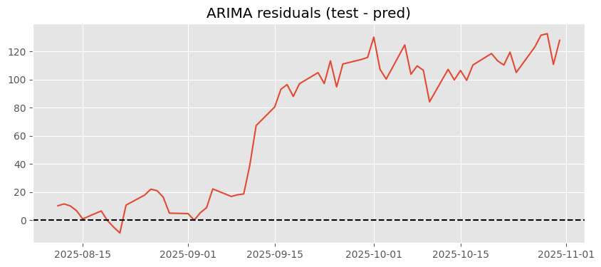

```python
plt.figure(figsize=(10,4))
plt.plot(test.index, test.values - arima_forecast.values)
plt.title('ARIMA residuals (test - pred)')
plt.axhline(0, color='k', linestyle='--')
plt.show()
```

## result saving

```python
out_df = pd.DataFrame({
    'actual': test.values,
    'arima_pred': arima_forecast.values,
    'reg_pred': reg_forecast.values
}, index=test.index)

out_csv = r"C:\Users\hp\Downloads\Tesla_stock_data\forecast_comparison_output.csv"
out_df.to_csv(out_csv)
print("\nSaved comparison CSV to:", out_csv)
```

```
Saved comparison CSV to: C:\Users\hp\Downloads\Tesla_stock_data\forecast_comparison_output.csv
```

Summary decision

```python
if arima_metrics['RMSE'] <= reg_metrics['RMSE']:
    recommended = 'ARIMA'
else:
    recommended = 'Regression'
print("\nRecommended model based on RMSE:", recommended)
```

```
Recommended model based on RMSE: ARIMA
```

# Project Conclusion and Recommendation

This project successfully implemented a comparative forecasting study using two distinct methodologies—ARIMA (a time-series statistical model) and Regression (a feature-based machine learning model)—to predict the closing price of Tesla stock.

## Final Model Comparison Results

[output not shown]

### Model Performance Summary

[output not shown]

## Recommendation

Based on the quantitative evaluation of the out-of-sample forecasts:

The **ARIMA Model** is the recommended choice for forecasting Tesla's stock price. Its error is within a plausible range for a volatile asset ($\text{RMSE} \approx \$84.14$), whereas the Regression model produced errors in the billions, indicating a complete failure in its predictive capacity.

## Project Overview and Conclusion

### Overview

The project met its objectives by developing and evaluating both models. However, the comparison revealed a critical outcome: the Regression model was unstable.

### Key Conclusion

The **ARIMA model is the clear winner**. Its statistical properties, which rely on smoothing and differencing to handle the inherent non-stationarity of stock prices, allowed it to generate a stable and far more accurate forecast than the Regression model.

The massive error in the Regression model strongly suggests a fundamental problem with its implementation, likely:

1. **Error Accumulation:** In a recursive prediction loop, small initial errors compounded exponentially, leading to instability.
2. **Stationarity Violation:** The Linear Regression model may have been trained directly on the non-stationary 'Close' price, causing the forecasts to "explode" over time.